# NYC flight delay analysis

Cole

2026-03-01

### Objective

This analysis evaluates factors associated with arrival delays for flights departing New York City airports. The goal is to identify actionable booking decisions passengers can make to reduce the likelihood of significant delays. Data were obtained from the `nycflights13` dataset containing commercial flights departing NYC airports in 2013.

### Stakeholders

- Airline passengers planning travel
- Business travelers sensitive to arrival times
- Travel planners seeking lower delay risk options

### Data cleaning

Flight data were enriched by merging airline and airport metadata. Duplicate and incomplete flight records were removed, and missing delay values were excluded. Datetime features and categorical delay classifications were created to support comparative analysis.

### Delay classification

- Arrival delay > 60 minutes is significant
- Arrival delay 15 to 60 minutes is high

### Exploratory analysis

Flights were grouped by airline, departure airport, day of week, and departure hour. For each group, the percentage of flights experiencing high or significant arrival delays was calculated. The following analysis evaluates how delay risk varies across key booking decisions available to stakeholders.

Airline Delay risk

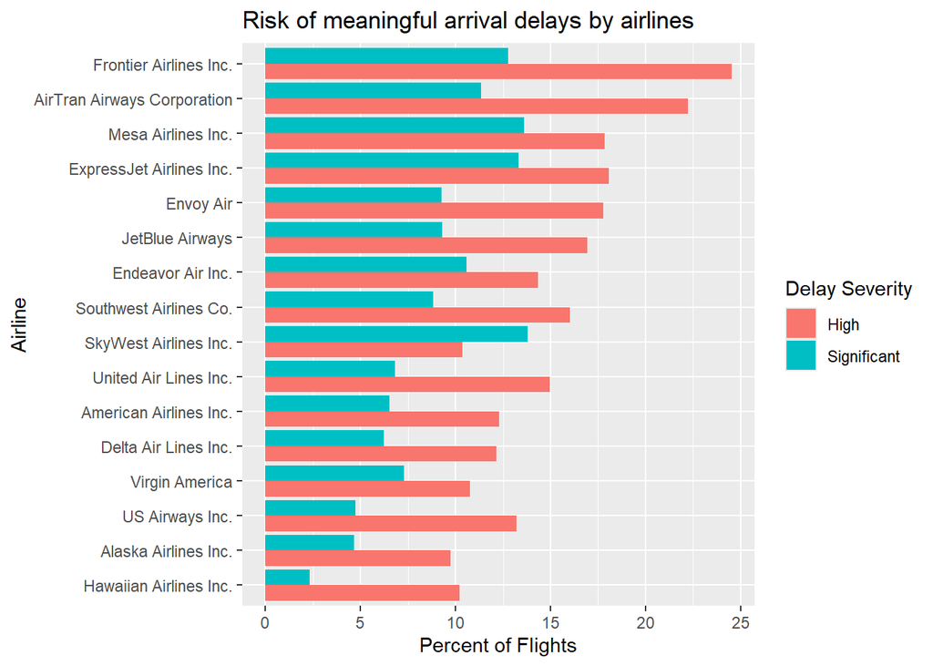

Insight: Substantial variation exists for both high and significant delay between the different airlines. This difference is clear when comparing Hawaiian Airlines, Alaska Airlines, and US Airways to Frontier Airlines, Airtran Airways, and Mesa Airlines.

Recommendation: Stakeholders should prefer airlines with demonstrable lower delay risk when possible.

Airport Origin Delay risk

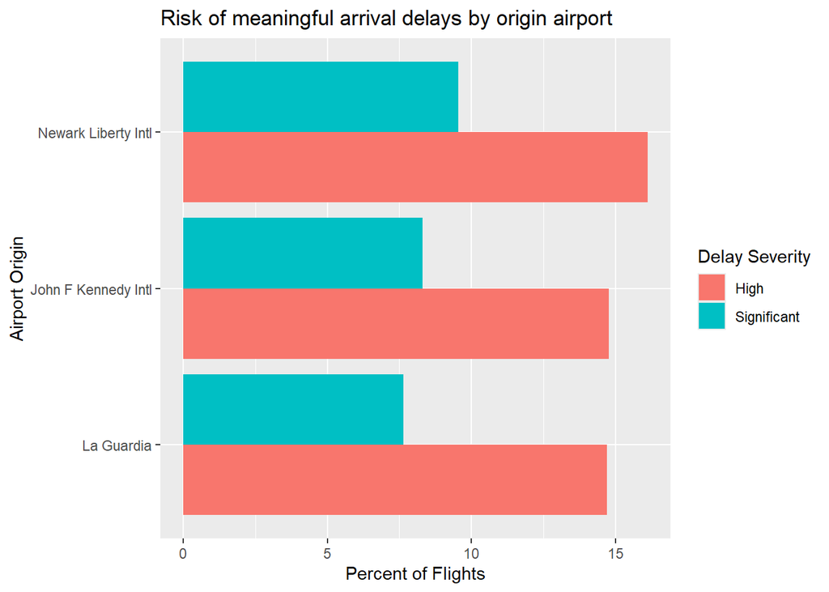

Insight: Small variation exists for both high and significant delay between the three airports. La Guardia demonstrates lower significant and high delay severity.

Recommendation: Stakeholders should prefer La Guardia for their departing airport when possible.

Day of the week delay plot

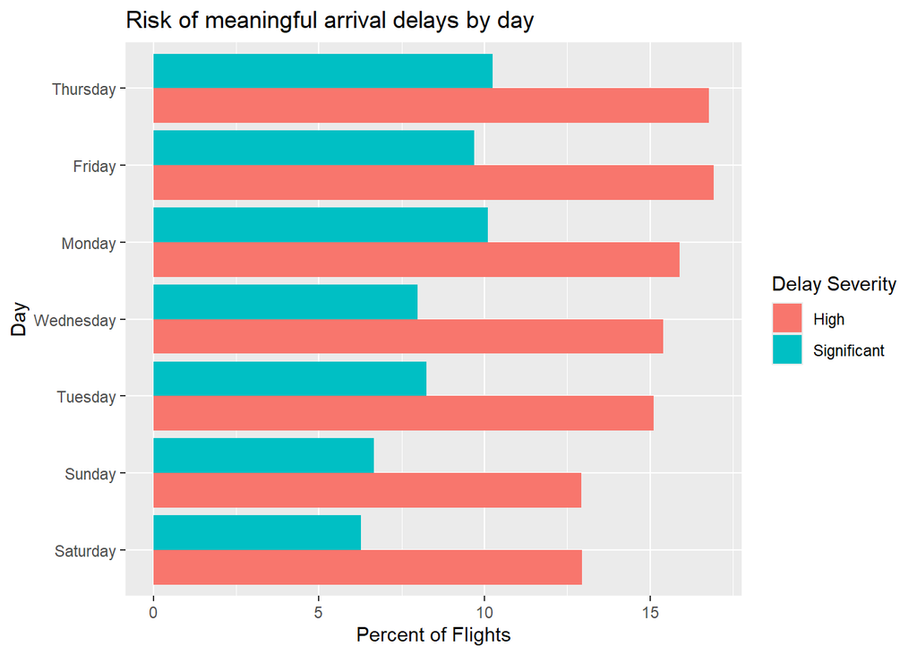

Insight: Moderate delay variation exists between the days. Saturday and Sunday show the lowest delay risk while Thursday has the highest.

Recommendation: Stakeholders should prioritize travelling on lower delay risk days.

Hour of day delay plot

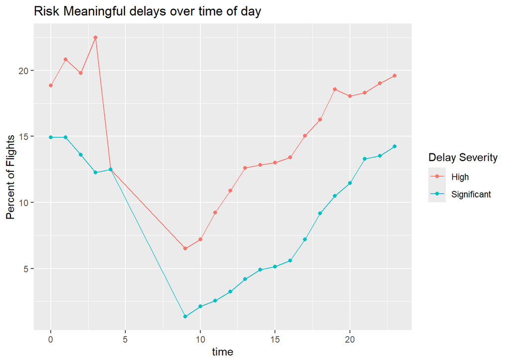

Insight: Substantial delay variation exists throughout the course of the day. Just before 10am experiences low delay, which increases gradually until after midnight, which is when the highest delay risks are experienced.

### Limitations

Analysis limited to 2013 data. Results describe historical patterns, not predictions.

### Future Work

Incorporate weather data. Model predictive delay probability. Extend analysis across multiple years.